[figure not shown]

# Apache Kafka

Realtime Data Processing

Maret 2025

Apache Kafka adalah platform streaming data terdistribusi yang digunakan untuk menangani data real-time dalam jumlah besar. Kafka sering digunakan untuk mengirim, menyimpan dan memproses data secara cepat antara sistem atau aplikasi yang berbeda.

🔹 Fungsi Utama Apache Kafka:

1. Publish dan Subscribe Pesan

   Kafka bekerja seperti sistem message broker, di mana produsen (producer) mengirim data, dan konsumen (consumer) menerima data.
2. Penyimpanan Data Secara Terdistribusi

   Kafka menyimpan data dalam bentuk log yang dapat diproses ulang kapan saja.
3. Pemrosesan Data Real-Time

   Kafka dapat memproses data secara langsung menggunakan Kafka Streams atau teknologi seperti Apache Flink & Spark.

🔹 Komponen Utama Apache Kafka

- **Producer**: Mengirim data ke Kafka (misalnya dari aplikasi, sensor, database)
- **Consumer**: Menerima data dari Kafka untuk diproses
- **Broker**: Server Kafka yang menyimpan data dan mengatur distribusi
- **Topic**: Saluran tempat data dikirimkan, seperti kategori atau jenis data
- **Partition**: Membagi data dalam satu topic untuk meningkatkan kecepatan dan skalabilitas
- **Zookeeper**: Mengelola cluster Kafka dan menjaga koordinasi antar node

Kafka Producer memiliki beberapa fitur utama:

- **Asynchronous Messaging**: Pesan dikirim secara asinkron untuk meningkatkan performa.
- **Message Batching**: Producer dapat mengirimkan beberapa pesan dalam satu batch untuk efisiensi.
- **Serialization**: Data dikonversi ke format yang dapat diproses oleh Kafka, seperti JSON atau Avro.
- **Acknowledgment (acks)**: Producer dapat mengonfirmasi apakah pesan telah diterima oleh Kafka.

Beberapa proses yang terjadi:

1. **Mengambil data** dari sumber eksternal seperti API atau database.
2. **Memproses atau memformat ulang data** agar sesuai dengan kebutuhan.
3. **Mengirim data ke Kafka Topics**, tempat penyimpanan sementara sebelum dikonsumsi oleh Consumer.
4. **Menyebarkan data ke berbagai partisi** dalam Kafka untuk load balancing dan parallel processing.

🔹 Cara Kerja Kafka (Alur Data)

1️⃣ Producer mengirim data ke Kafka Topic

2️⃣ Kafka menyimpan data di Brokers dalam bentuk partisi

3️⃣ Consumer membaca data dari Kafka

4️⃣ Data dapat diproses lebih lanjut atau disimpan dalam database

🔹 Contoh Penggunaan Apache Kafka

✅ Streaming Data Log & Monitoring (contoh: Logging server seperti ELK, Splunk)

✅ Proses Data Sensor IoT (contoh: Data dari smart devices)

✅ Pengolahan Data Finansial (contoh: Transaksi real-time di bank)

✅ Integrasi Microservices (contoh: Komunikasi antar layanan backend)

✅ Big Data Processing (contoh: Dengan Hadoop, Spark, atau Flink)

### Sumber Data:

Menggunakan API dari https://randomuser.me/ yang akan mengenerate user secara acak

Parameter yang diambil hanya:

1. Gender = Jenis kelamin
2. Name = Nama (yang terdiri dari Titel, Nama Depan dan Nama Belakang)
3. Nat = Kebangsaan
4. Phone = Nomor telepon

Disusun dengan format Pretty JSON

```python
import requests

url = "https://randomuser.me/api/?inc=gender,name,nat,phone&format=prettyJSON"

response = requests.get(url)

if response.status_code == 200:
    data = response.json()
    print(data)  # Print the entire response
else:
    print(f"Error: {response.status_code}")
```

```
{'results': [{'gender': 'female', 'name': {'title': 'Madame', 'first': 'Viviane', 'last': 'Vidal'}, 'phone': '078 338 23 37', 'nat': 'CH'}], 'info': {'seed': 'a36cbb9b0b403a9a', 'results': 1, 'page': 1, 'version': '1.4'}}
```

```python
data
```

```
{'results': [{'gender': 'female',
   'name': {'title': 'Madame', 'first': 'Viviane', 'last': 'Vidal'},
   'phone': '078 338 23 37',
   'nat': 'CH'}],
 'info': {'seed': 'a36cbb9b0b403a9a',
  'results': 1,
  'page': 1,
  'version': '1.4'}}
```

Merapihkan data yang akan digunakan

```python
result = data['results'][0]  # Get the first user
row_data = {
        "Title": result['name']['title'],
        "First Name": result['name']['first'],
        "Nationality": result['nat'],
        "Last Name": result['name']['last'],
        "Gender": result['gender'],
        "Phone": result['phone']
    }

row_data
```

```
{'Title': 'Madame',
 'First Name': 'Viviane',
 'Nationality': 'CH',
 'Last Name': 'Vidal',
 'Gender': 'female',
 'Phone': '078 338 23 37'}
```

### Persiapan Data:

Kafka hanya menerima data dalam format **byte string**, sehingga kita perlu mengonversinya terlebih dahulu dengan tahapan:

1. **Mengonversi dictionary ke JSON** (`json.dumps(row_data)`).
2. **Mengonversi ke format byte** (`encode('utf-8')`).

```python
message = json.dumps(row_data).encode('utf-8')
message
```

```
b'{"Title": "Madame", "First Name": "Viviane", "Nationality": "CH", "Last Name": "Vidal", "Gender": "female", "Phone": "078 338 23 37"}'
```

### Kafka Producer

Untuk membuat Kafka Producer di Python, kita akan menggunakan pustaka `confluent_kafka` untuk mengirimkan Random User ke Kafka. Sebelum mengirimkan data, kita perlu mengatur konfigurasi Producer terlebih dahulu.

Sebelum memulai, pastikan bahwa:

- Kafka sudah terinstal di sistem.
- Memiliki pustaka Python `confluent_kafka`
- Kafka sedang berjalan.

Sebelum menjalankan Kafka Producer, pastikan bahwa Kafka sudah berjalan di mesin kita. Untuk menjalankannya, kita gunakan sistem Docker Container, pada kesempatan ini digunakan Docker Desktop lokal.

**1. Konfigurasi Server dan Port**

Kafka Producer harus mengetahui **alamat dan port** dari Kafka Cluster agar dapat mengirim pesan. Konfigurasi ini dilakukan melalui `bootstrap.servers`, yang menentukan alamat broker Kafka yang akan digunakan untuk mengirimkan data.

Agar dapat mengirim data ke Kafka, kita harus membuat Kafka Producer dengan konfigurasi berikut:

- `bootstrap.servers`: Menentukan alamat broker Kafka yang akan digunakan, pada kesempatan ini di localhost:9092
- `client.id`: ID unik untuk mengenali producer ini.

```python
from confluent_kafka import Producer

KAFKA_CONFIG = {"bootstrap.servers" : "localhost:9092",
        "client.id" : "random-user-producer"}
```

Selanjutnya, kita membuat instance `Producer` dengan konfigurasi yang telah ditentukan sebelumnya. Fungsi `Producer()` dari pustaka `confluent_kafka` digunakan untuk menginisialisasi producer Kafka yang akan mengelola koneksi dengan broker Kafka.

```python
producer = Producer(KAFKA_CONFIG)
```

**2. Topics and Message Structure (Key-Value Pair)**

Kafka menyimpan pesan dalam **Topics**, yang berfungsi seperti "folder" tempat data dikelompokkan. Setiap pesan yang dikirimkan ke Kafka memiliki format **Key-Value Pair**, yang memungkinkan Kafka melakukan partisi data berdasarkan **Key** tertentu.

Mari kita tentukan topik Kafka serta interval pengiriman data:

```python
TOPIC = 'random-user-topic'
INTERVAL = 30
```

**3. Kirim Ke Kafka Producer**

Setelah data siap, kita dapat mengirimkan pesan ke Kafka menggunakan

- `produce(TOPIC, message)`: Mengirimkan pesan ke topik Kafka.
- `flush()`: Memastikan semua data terkirim sebelum program selesai dieksekusi.

```python
producer.produce(topic = TOPIC, value = message)
producer.flush()
```

```
0
```

# Kafka Consumer

adalah komponen dalam Apache Kafka yang berfungsi untuk menerima dan membaca pesan yang dikirim oleh Kafka Producer melalui Kafka Topic.

Consumer bekerja dengan cara berlangganan (subscribe) ke satu atau lebih topic di Kafka dan membaca pesan yang masuk secara real-time.

🔹 Cara Kerja Kafka Consumer

1️⃣ Consumer berlangganan (subscribe) ke Topic

2️⃣ Kafka menyimpan data dalam partisi (partition)

3️⃣ Consumer membaca data berdasarkan offset (urutan pesan)

4️⃣ Kafka tidak akan menghapus data secara langsung, sehingga consumer dapat membaca ulang jika diperlukan

5️⃣ Jika ada banyak consumer dalam satu grup, Kafka akan membagi tugas membaca data secara otomatis

🔹 Komponen Utama Kafka Consumer

- **Topic**: Saluran tempat pesan dikirim
- **Partition**: Kafka membagi data ke dalam beberapa partisi untuk meningkatkan performa
- **Offset**: Posisi atau indeks pesan yang terakhir dibaca oleh consumer
- **Consumer Group**: Sekumpulan consumer yang bekerja bersama untuk membaca pesan dari Kafka
- **Commit Offset**: Kafka menyimpan informasi tentang pesan terakhir yang telah dibaca

🔹 Kafka Consumer Group

- Consumer Group adalah kumpulan beberapa consumer yang membaca dari satu topic yang sama.
- Kafka akan mendistribusikan partisi data secara otomatis ke setiap consumer dalam grup.
- Jika ada lebih banyak consumer daripada partisi, beberapa consumer akan idle (tidak membaca data).

**1️⃣ Server and Port Configuration**

Sebelum membuat Consumer, kita perlu mengonfigurasikan beberapa parameter penting:

- **`bootstrap.servers`** → Menentukan alamat dan port broker Kafka yang digunakan untuk menerima data.
- **`group.id`** → Mengelompokkan beberapa Consumer agar bisa membaca data secara bersamaan tanpa duplikasi.
- **`auto.offset.reset`** → Mengontrol dari mana Consumer mulai membaca pesan:
  - `earliest` → Membaca dari awal jika belum ada offset yang disimpan.
  - `latest` → Membaca hanya pesan terbaru.
- **`enable.auto.commit`** → Jika `True`, Kafka akan otomatis menyimpan posisi offset. Jika `False`, kita perlu melakukan commit offset secara manual untuk lebih banyak kontrol.

Berikut konfigurasi dasarnya:

```python
import pandas as pd
import json
from confluent_kafka import Consumer, KafkaException, KafkaError

pd.options.display.float_format = '{:,.3f}'.format
```

**1. Konfigurasi Kafka Consumer**  
Sebelum dapat membaca data dari Kafka, kita perlu mengatur beberapa konfigurasi dasar untuk **Kafka Consumer**.

```python
# Konfigurasi Kafka Consumer
consumer_config = {
    "bootstrap.servers": "localhost:9092",
    "group.id": "random-user-group",
    "auto.offset.reset": "earliest"
}
```

**2. Membuat Kafka Consumer**  
Setelah mengatur konfigurasi, kita perlu membuat objek **Consumer** yang akan digunakan untuk membaca data dari Kafka.

- Menggunakan `Consumer()` menerima parameter berupa konfigurasi yang sudah kita definisikan sebelumnya (`consumer_config`).
- Buat variabel `consumer` yang akan digunakan untuk menerima data dari Kafka.

```python
consumer = Consumer(consumer_config)
```

**3. Subscribe ke Topik Kafka**  
Untuk mengakses data dari Kafka, kita perlu menentukan **topik** mana yang akan dibaca.

```python
# Subscribe ke topik Kafka
topic_name = 'random-user-topic'
```

```python
consumer.subscribe([topic_name])
```

**Additional:**

- Jika terdapat beberapa topik yang ingin dibaca, kita bisa memberikan daftar topik, misalnya:

  ```
  consumer.subscribe(["topic1", "topic2"])
  ```

**2️⃣ Fetch Data from Kafka**

🔄 Polling Data dari Kafka

Kafka Consumer menggunakan metode **`poll(timeout)`** untuk menunggu dan mengambil data dari Kafka. Parameter `timeout` menentukan berapa lama Consumer akan menunggu pesan sebelum mencoba lagi.

```python
msg = consumer.poll(timeout=1.0)
```

- **`poll(timeout=1.0)`** → Memerintahkan consumer untuk mengambil pesan dari Kafka dengan batas waktu **1 detik**.
- Jika ada pesan yang tersedia dalam antrean Kafka, `poll()` akan segera mengembalikan pesan tersebut.
- Jika tidak ada pesan dalam waktu yang ditentukan, `poll()` akan mengembalikan `None`.

```python
msg
```

```
<cimpl.Message at 0x11eb41cc0>
```

- Kafka berhasil mengembalikan sebuah **objek pesan** (`Message`) yang berisi data dari Kafka.
- **`cimpl.Message`** adalah objek yang merepresentasikan pesan Kafka dalam library `confluent-kafka`.
- `0x11eb41cc0` adalah alamat memori tempat objek `Message` ini disimpan (akan berbeda setiap kali dijalankan).

Jika ingin melihat isi pesan yang sebenarnya, kita bisa mentransform atau decode pesan dari *bytes* ke *string*

```python
msg.value().decode('utf-8')
```

```
'{"Title": "Mrs", "First Name": "Rosalinde", "Last Name": "Greb", "Gender": "female", "Phone": "0948-7585689"}'
```

**3️⃣ Process and Store Data**

📝 Memproses Data yang Diterima

Setelah menerima pesan dari Kafka, kita perlu mengonversinya ke dalam format yang mudah digunakan. Di sini, kita akan menggunakan **`json.loads()`** untuk mengubah JSON menjadi dictionary Python.

```python
# List awal untuk menyimpan data
random_user_data=[]
```

**2. Parsing Data JSON dari Kafka**  
Ketika kita menerima pesan dari Kafka, pesan tersebut biasanya dalam format JSON. Oleh karena itu, kita perlu mengonversi pesan tersebut ke dalam bentuk dictionary Python menggunakan `json.loads()`.

```python
# Parsing data
random_user_data_point = json.loads(msg.value().decode('utf-8'))
```

- **`json.loads()`**: Mengonversi string JSON menjadi dictionary Python yang bisa kita akses lebih lanjut.

**3. Menambahkan Data ke dalam List**  
Setelah kita mendapatkan data yang sudah diproses, kita akan menambahkannya ke dalam list `random_user_data` untuk menyimpan setiap titik data.

```python
random_user_data.append(random_user_data_point)
```

**4. Mengubah List Menjadi Dataframe untuk Analisis Lebih Lanjut**  
Setelah beberapa data terkumpul, kita bisa mengubah list tersebut menjadi sebuah **Dataframe** menggunakan `pandas`, yang memudahkan analisis lebih lanjut dan visualisasi data.

```python
# Mengubah list menjadi DataFrame untuk analisis lebih lanjut
random_user_data_df = pd.DataFrame(random_user_data, columns=['Title', 'First Name', 'Last Name', 'Gender', 'Phone'])
random_user_data_df
```

|  | Title | First Name | Last Name | Gender | Phone |
| --- | --- | --- | --- | --- | --- |
| 0 | Ms | Olivia | Woods | female | 021-018-1790 |
| 1 | Mrs | Ruby | White | female | (764)-202-1525 |
| 2 | Mr | Koray | Topaloğlu | male | (154)-087-8658 |
| 3 | Mr | Adam | Johansen | male | 40788322 |
| 4 | Miss | Camila | Johnson | female | 08-2096-6197 |
| 5 | Mr | Liam | Hall | male | (403)-562-3085 |
| 6 | Mr | Noah | Robinson | male | (048)-480-8057 |
| 7 | Mr | Augustin | Richard | male | 03-78-56-50-51 |
| 8 | Mr | Barış | Tekand | male | (143)-511-3515 |

**[Tambahan]**

Menghitung jumlah masing-masing jenis kelamin user yang muncul untuk dibuatkan line plot sederhana

```python
# Count occurrences of each gender
gender_counts = random_user_data_df['Gender'].value_counts()

display(gender_counts)
```

```
Gender
male      6
female    3
Name: count, dtype: int64
```

**🖥️ Display Real-time Data**

Karena kita ingin memantau data secara real-time, kita perlu memperbarui DataFrame secara terus-menerus dengan polling data dari Kafka. Dalam hal ini, kita akan menggunakan **loop yang berjalan terus-menerus** dan memperbarui tampilan di Jupyter Notebook dengan pembaruan data secara real-time.

### `try`, `except`, dan `finally`

Blok **`try-except-finally`** digunakan untuk menangani error atau pengecualian (exception) yang mungkin terjadi saat menjalankan kode. Struktur ini membantu program untuk tetap berjalan meskipun ada error dan untuk memastikan kode tertentu dieksekusi, terlepas dari apakah error terjadi atau tidak.

**Struktur General `try`, `except`, dan `finally`**

- **`try`**: Di dalam blok ini, kita menulis kode yang mungkin menyebabkan error. Jika error terjadi, eksekusi kode akan berpindah ke blok **`except`**.
- **`except`**: Blok ini menangani error yang terjadi dalam blok **`try`**. Kita dapat menentukan jenis error tertentu atau menangani semua jenis error. Jika ada error di blok **`try`**, maka kode di dalam **`except`** yang sesuai dengan error tersebut akan dijalankan.
- **`finally`**: Blok ini dijalankan **terlepas dari apakah ada error atau tidak**. Biasanya digunakan untuk menutup file, melepaskan resource, atau menutup koneksi (seperti yang dilakukan dengan `consumer.close()` di contoh kita).

```
try:
    # Diisi dengan kode yang mungkin menyebabkan error
    pass  # Misalnya, membuka file atau melakukan koneksi database

except ExceptionType:
    # Diisi dengan kode untuk menangani error
    pass  # Menangani error tertentu (misalnya, FileNotFoundError)

finally:
    # Diisi dengan kode yang ingin dijalankan terlepas dari apakah ada error atau tidak
    pass  # Menutup koneksi atau membersihkan resource
```

**1️⃣ `try`**

Di dalam blok **`try`**, kita akan memasukkan beberapa kode yang bertanggung jawab untuk menjalankan polling data dari Kafka dan memprosesnya sesuai dengan kebutuhan. Pada kasus ini, kita menambahkan **loop polling**, **pemeriksaan error**, **parsing data**, dan **update tampilan real-time**.

Secara umum, kode di dalam blok **`try`** akan terus dieksekusi selama tidak ada error yang terjadi. Jika ada error, maka eksekusi akan berpindah ke blok **`except`**.

#### **2️⃣ `except`**

Pada bagian **`except`**, kita akan menangani error atau kejadian tertentu yang terjadi selama eksekusi kode dalam blok **`try`**. Dalam hal ini, kita akan menangani error **`KeyboardInterrupt`**, yang biasanya terjadi ketika pengguna menekan tombol **Ctrl + C** untuk menghentikan proses. Logika yang digunakan adalah, ketika tombol **stop** ditekan, maka program akan berhenti secara aman dan menampilkan pesan **"Stopped by user"**.

```
except KeyboardInterrupt:
    print("Stopped by user")
```

#### **3️⃣ `finally`**

Pada bagian **`finally`**, kita akan menambahkan kode yang harus dieksekusi terlepas dari apakah terjadi error atau tidak dalam blok **`try`** dan **`except`**. Pada kasus ini, kita akan menutup Kafka Consumer dengan cara memanggil **`consumer.close()`**, untuk memastikan koneksi dengan Kafka ditutup dengan aman saat program dihentikan.

Contoh kode:

```
finally:
    consumer.close()  # Menutup Kafka Consumer dengan aman
```

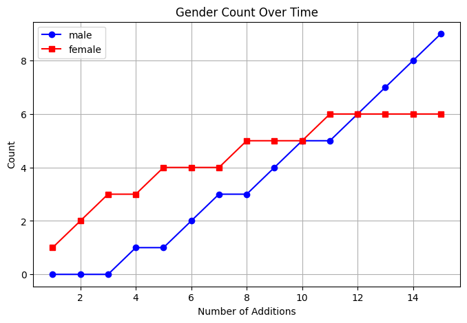

|  | Title | First Name | Last Name | Gender | Phone |
| --- | --- | --- | --- | --- | --- |
| 0 | Miss | Séléna | Chevalier | female | 03-52-65-47-12 |
| 1 | Madame | Annie | Gautier | female | 077 261 55 34 |
| 2 | Ms | Margot | Sanchez | female | 04-79-97-87-58 |
| 3 | Mr | Sami | Lagesen | male | 72407906 |
| 4 | Mrs | Alexis | Taylor | female | (473)-412-5992 |
| 5 | Mr | Nathaniel | Brown | male | (949)-969-3801 |
| 6 | Mr | Eemeli | Puro | male | 02-941-346 |
| 7 | Miss | Hiske | Broeken | female | (008) 4487509 |
| 8 | Mr | Vedat | Mayhoş | male | (628)-984-5521 |
| 9 | Mr | Andreas | Christiansen | male | 85819190 |
| 10 | Ms | Laura | Møller | female | 90242902 |
| 11 | Mr | Kevin | Hart | male | (439) 584-1344 |
| 12 | Mr | Mijat | Srećković | male | 030-3797-758 |
| 13 | Mr | پوریا | رضاییان | male | 067-22401238 |
| 14 | Mr | Joey | Burton | male | 013873 56847 |

```
Stopped by user
```

```python
import pandas as pd
import json
from confluent_kafka import Consumer, KafkaError
import time
import matplotlib.pyplot as plt
from IPython.display import display, clear_output

pd.options.display.float_format = '{:,.3f}'.format

# Kafka Consumer Configuration
consumer_config = {
    "bootstrap.servers": "localhost:9092",
    "group.id": "random-user-group",
    "auto.offset.reset": "earliest"
}

consumer = Consumer(consumer_config)
topic_name = 'random-user-topic'
consumer.subscribe([topic_name])

# Initialize gender counts and historical data
gender_counts = {"male": 0, "female": 0}
history = {"Step": [], "male": [], "female": []}
step_counter = 0  # Track steps for plotting

# Function to update the line plot
def update_plot():
    plt.figure(figsize=(8, 5))
    plt.plot(history["Step"], history["male"], marker='o', linestyle='-', label="male", color='blue')
    plt.plot(history["Step"], history["female"], marker='s', linestyle='-', label="female", color='red')

    plt.xlabel("Number of Additions")
    plt.ylabel("Count")
    plt.title("Gender Count Over Time")
    plt.legend()
    plt.grid(True)

    clear_output(wait=True)  # Clear previous output to refresh display
    plt.show()

# List to store received data
random_user_data = []

# Kafka Consumer Loop
try:
    while True:
        msg = consumer.poll(timeout=1.0)

        if msg is None:
            continue
        if msg.error():
            if msg.error().code() == KafkaError._PARTITION_EOF:
                continue
            else:
                print(f"Kafka Error: {msg.error()}")
                break

        # Parse JSON message from Kafka
        random_user_data_point = json.loads(msg.value().decode("utf-8"))
        random_user_data.append(random_user_data_point)

        # Create DataFrame from collected data
        random_user_df = pd.DataFrame(random_user_data)

        # Check if "Gender" exists before counting
        if "Gender" in random_user_df.columns:
            # Count occurrences of each gender
            gender = random_user_data_point.get("Gender", None)
            if gender in gender_counts:
                gender_counts[gender] += 1
                step_counter += 1  # Increment step count

                # Update history for plotting
                history["Step"].append(step_counter)
                history["male"].append(gender_counts["male"])
                history["female"].append(gender_counts["female"])

                # Update the plot
                update_plot()


        display(random_user_df)
        time.sleep(1)  # Delay to prevent excessive CPU usage

except KeyboardInterrupt:
    print("Stopped by user")

finally:
    consumer.close()  # Safely close the Kafka consumer
```